# Forest Fires in Portugal - What Are The Causes?

Practical Assignment of Data Mining I

By Robson Teixeira, Eduardo Rodrigues and Claudio Rocha

M:CC – FCUP, 10/01/2021

# 1 Introduction

# 2 Problem Definition

Forest fires are a very important issue that negatively affects climate change. Typically, the causes of forest fires are those oversights, accidents and negligence committed by individuals, intentional acts and natural causes. The latter is the root cause for only a minority of the fires.

Their harmful impacts and effects on ecosystems can be major ones. Among them, we can mention the disappearance of native species, the increase in levels of carbon dioxide in the atmosphere, earth’s nutrients destroyed by the ashes, and the massive loss of wildlife.

Data mining techniques can help in the prediction of the cause of the fire and, thus, better support the decision of taking preventive measures in order to avoid tragedy. In effect, this can play a major role in resource allocation, mitigation and recovery efforts.

# 3 Forest Fire Dataset

The ICFN - Nature and Forest Conservation Institute has the record of the list of forest fires occurred in Portugal for several years. For each fire, there is information such as the site, the alert date/hour, the extinction date/hour, the affected area and the cause type. A classifications for causes types are presented in table @ref(tab:cause_type).

Table 1: (#tab:cause_type) Classifications of causes of forest fires.

| Cause | Description |
| --- | --- |
| Unknown | absence of suficient objective evidence to determine the cause of the ignition of fire |
| Natural | lightning generated in thunderstorms |
| Negligence | the misguided use of fire in activities such as burning trash, mass burning of agricultural and forest fuels, fun and leisure activities; failure to properly extinguish cigarettes by smokers; the disp… |
| Intentional | incendiarism and arson, mostly resulting from behaviors and attitudes reacting to theconstraints of agroforestry management systems and to conflicts related to land use |
| Rekindling | reburning of an area over which a fire has previously passed, but where fuel has been left that is later ignited by latent heat, sparks, or embers |

The dataset used in this study was provided by ICFN, and it contains the data on reported forest fires during 2015 and its respective causes. The data are distributed in files:

- **fires2015train.csv** — the file contain the data of 7511 reported forest fires during 2015

A summary of the structure of it and a glimpse of their first rows are provided below.

```
## Rows: 7,511
## Columns: 21
## $ id                 <int> 1, 2, 3, 4, 5, 6, 7, 8, 9, 10, 11, 12, 13, 14, 1...
## $ region             <chr> "Entre Douro e Minho", "Entre Douro e Minho", "T...
## $ district           <chr> "Viana do Castelo", "Porto", "Vila Real", "Vila ...
## $ municipality       <chr> "Ponte de Lima", "Marco de Canaveses", "Boticas"...
## $ parish             <chr> "Serdedelo", "Vila Boa de Quires", "Cerdedo", "G...
## $ lat                <chr> "41:44:48.5663999999878''", "41:12:58.4280000000...
## $ lon                <chr> "8:31:12.3276000000027''", "8:12:28.378800000002...
## $ origin             <chr> "fire", "fire", "fire", "firepit", "firepit", "f...
## $ alert_date         <chr> "2015-03-24", "2015-03-24", "2015-03-24", "2015-...
## $ alert_hour         <chr> "17:01:00", "17:10:00", "21:40:00", "16:00:00", ...
## $ extinction_date    <chr> "2015-03-24", "2015-03-24", "2015-03-25", "2015-...
## $ extinction_hour    <chr> "18:09:00", "18:47:00", "05:45:00", "17:00:00", ...
## $ firstInterv_date   <chr> "2015-03-24", "2015-03-24", "2015-03-24", "2015-...
## $ firstInterv_hour   <chr> "17:10:00", "17:16:00", "22:00:00", "16:14:00", ...
## $ alert_source       <lgl> NA, NA, NA, NA, NA, NA, NA, NA, NA, NA, NA, NA, ...
## $ village_area       <dbl> 2.50, 0.00, 0.50, 0.00, 0.10, 0.00, 0.35, 0.50, ...
## $ vegetation_area    <dbl> 0.000, 1.350, 38.000, 0.010, 0.000, 0.100, 14.82...
## $ farming_area       <dbl> 0.0000, 0.0000, 0.0000, 0.0000, 0.0000, 0.0000, ...
## $ village_veget_area <dbl> 2.500, 1.350, 38.500, 0.010, 0.100, 0.100, 15.17...
## $ total_area         <dbl> 2.5000, 1.3500, 38.5000, 0.0100, 0.1000, 0.1000,...
## $ cause_type         <chr> "negligent", "negligent", "negligent", "negligen...
```

```
## # A tibble: 6 x 21
##      id region district municipality parish lat   lon   origin alert_date
##   <int> <chr>  <chr>    <chr>        <chr>  <chr> <chr> <chr>  <chr>
## 1     1 Entre~ Viana d~ Ponte de Li~ Serde~ 41:4~ 8:31~ fire   2015-03-24
## 2     2 Entre~ Porto    Marco de Ca~ Vila ~ 41:1~ 8:12~ fire   2015-03-24
## 3     3 Trás-~ Vila Re~ Boticas      Cerde~ 41:3~ 07:5~ fire   2015-03-24
## 4     4 Trás-~ Vila Re~ Montalegre   Gralh~ 41:5~ 7:42~ firep~ 2015-03-25
## 5     5 Trás-~ Vila Re~ Valpaços     Alger~ 41:3~ 07:2~ firep~ 2015-03-12
## 6     6 Entre~ Vila Re~ Mondim de B~ Ermelo 41:2~ 07:5~ firep~ 2015-03-13
## # ... with 12 more variables: alert_hour <chr>, extinction_date <chr>,
## #   extinction_hour <chr>, firstInterv_date <chr>, firstInterv_hour <chr>,
## #   alert_source <lgl>, village_area <dbl>, vegetation_area <dbl>,
## #   farming_area <dbl>, village_veget_area <dbl>, total_area <dbl>,
## #   cause_type <chr>
```

```
##              variable q_zeros p_zeros q_na   p_na q_inf p_inf      type unique
## 1                  id       0    0.00    0   0.00     0     0   integer   7511
## 2              region       0    0.00  501   6.67     0     0 character     10
## 3            district       0    0.00    0   0.00     0     0 character     19
## 4        municipality       0    0.00    0   0.00     0     0 character    297
## 5              parish       0    0.00    0   0.00     0     0 character   2270
## 6                 lat       0    0.00    0   0.00     0     0 character   5858
## 7                 lon       0    0.00    0   0.00     0     0 character   5867
## 8              origin       0    0.00    0   0.00     0     0 character      5
## 9          alert_date       0    0.00    0   0.00     0     0 character    317
## 10         alert_hour       0    0.00    0   0.00     0     0 character   1312
## 11    extinction_date       0    0.00    9   0.12     0     0 character    319
## 12    extinction_hour       0    0.00    9   0.12     0     0 character   1201
## 13   firstInterv_date       0    0.00  214   2.85     0     0 character    318
## 14   firstInterv_hour       0    0.00  215   2.86     0     0 character   1202
## 15       alert_source       0    0.00 7511 100.00     0     0   logical      0
## 16       village_area    5349   71.22    0   0.00     0     0   numeric    591
## 17    vegetation_area    2648   35.25    0   0.00     0     0   numeric   1052
## 18       farming_area    5976   79.56    0   0.00     0     0   numeric    650
## 19 village_veget_area    1413   18.81    0   0.00     0     0   numeric   1377
## 20         total_area       8    0.11    0   0.00     0     0   numeric   1781
## 21         cause_type       0    0.00    0   0.00     0     0 character      4
```

```
## # A tibble: 6 x 21
##      id region district municipality parish lat   lon   origin alert_date
##   <int> <chr>  <chr>    <chr>        <chr>  <chr> <chr> <chr>  <chr>
## 1  7506 Trás-~ Bragança Mirandela    Carva~ 41:3~ 7:10~ firep~ 2015-07-18
## 2  7507 Beira~ Castelo~ Idanha-a-No~ Oledo  39:5~ 7:20~ firep~ 2015-08-07
## 3  7508 Entre~ Porto    Penafiel     São M~ 41:1~ 8:12~ firep~ 2015-08-08
## 4  7509 Entre~ Porto    Amarante     Telões 41:1~ 8:6:~ firep~ 2015-08-08
## 5  7510 Entre~ Braga    Celorico de~ Gémeos 41:2~ 8:0:~ firep~ 2015-08-08
## 6  7511 Ribat~ Santarém Ourém        Nossa~ 39:3~ 8:34~ firep~ 2015-08-08
## # ... with 12 more variables: alert_hour <chr>, extinction_date <chr>,
## #   extinction_hour <chr>, firstInterv_date <chr>, firstInterv_hour <chr>,
## #   alert_source <lgl>, village_area <dbl>, vegetation_area <dbl>,
## #   farming_area <dbl>, village_veget_area <dbl>, total_area <dbl>,
## #   cause_type <chr>
```

Table @ref(tab:variables) describes all variables contained in the `fires.raw` of the data set. Clearly, the type of some of variables is incorrect and inconvenient for analysis and that was taken care of in section @ref(data-cleaning).

(#tab:variables) List of variables present in the original file from the fires2015train.csv data set.

| Variable | Type | Description |  |
| --- | --- | --- | --- |
| id | integer | id number |  |
| region | character | region name |  |
| district | character | district name |  |
| municipality | character | municipality name |  |
| parish | character | parish name |  |
| lat | character | latitude value |  |
| lon | character | longitude value |  |
| origin | character | how the fire started |  |
| alert_date | character | date when fire started |  |
| alert_hour | character | alert hour |  |
| extinction_date | character | date of the end of fire |  |
| extinction hour | character | hour of the end of fire |  |
| firstInterv_date | character | date of intervention |  |
| firstInterv_hour | character | hour of intervention |  |
| alert_source | logical | alert source |  |
| village_area | numeric | village area affected |  |
| alert_source | logical | alert source |  |
| village_area | numeric | village area affected |  |
| vegetation_area | numeric | vegetation area affected |  |
| farming_area | numeric | farming area affected |  |
| village_veget_area | numeric | total village+veget affected |  |
| total_area | numeric | total area affected |  |
| cause_type | character | cause of the fire |  |

## 3.1 Graphic analysis

1- Bar plot of forests fires during 2015

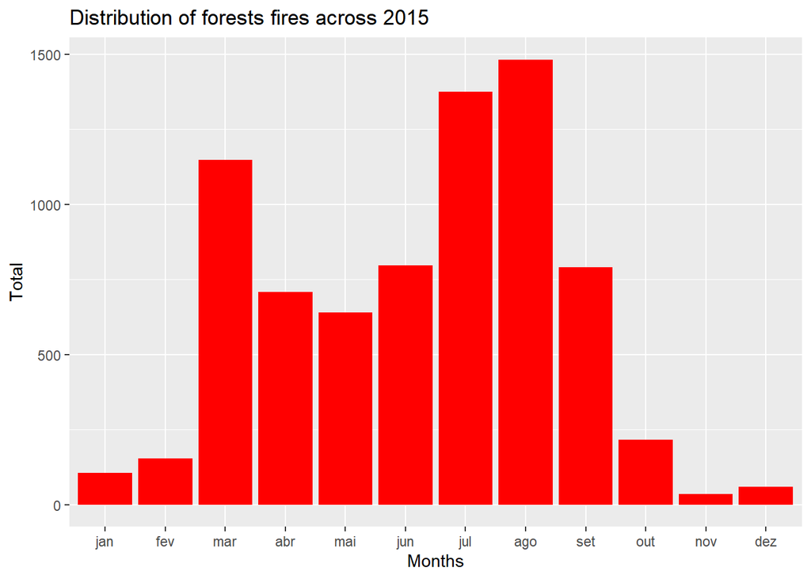

Conclusion: july and august were the months with a great number of ocurrences

2- bar plot of forests fires during 2015 by region

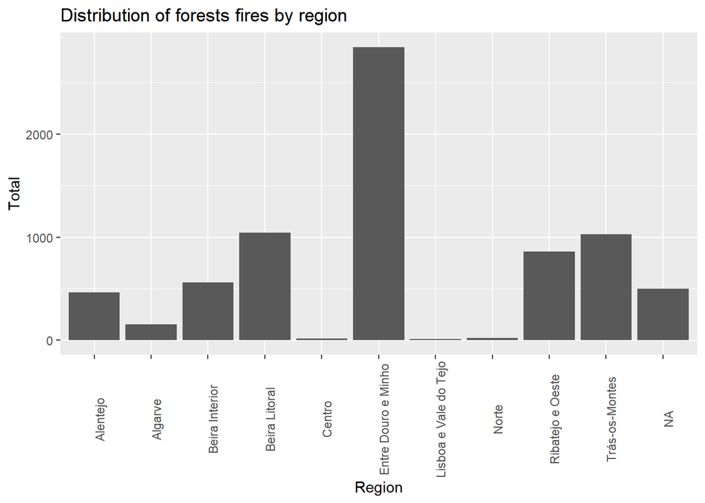

Conclusion: Entre Douro e Minho was the region with mores forests fires

3- bar plot of forests fires during 2015 by district

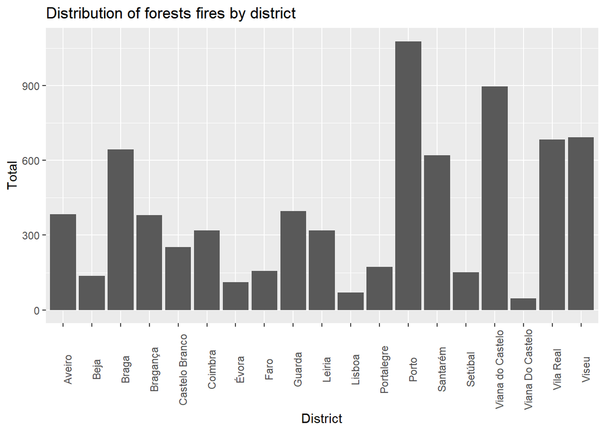

Conclusion: Porto was the district with more forests fires

4- bar plot of forests fires during 2015 by causes

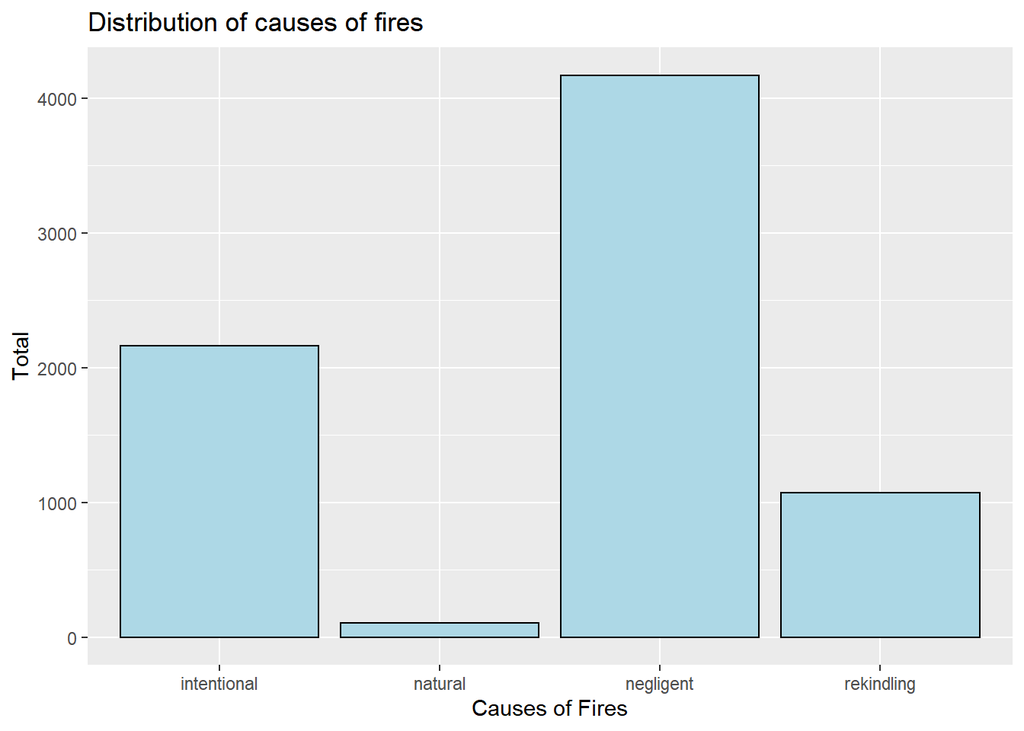

Conclusion: negligence was the big cause of the forests fires

5- bar plot of forests fires during 2015 by origin

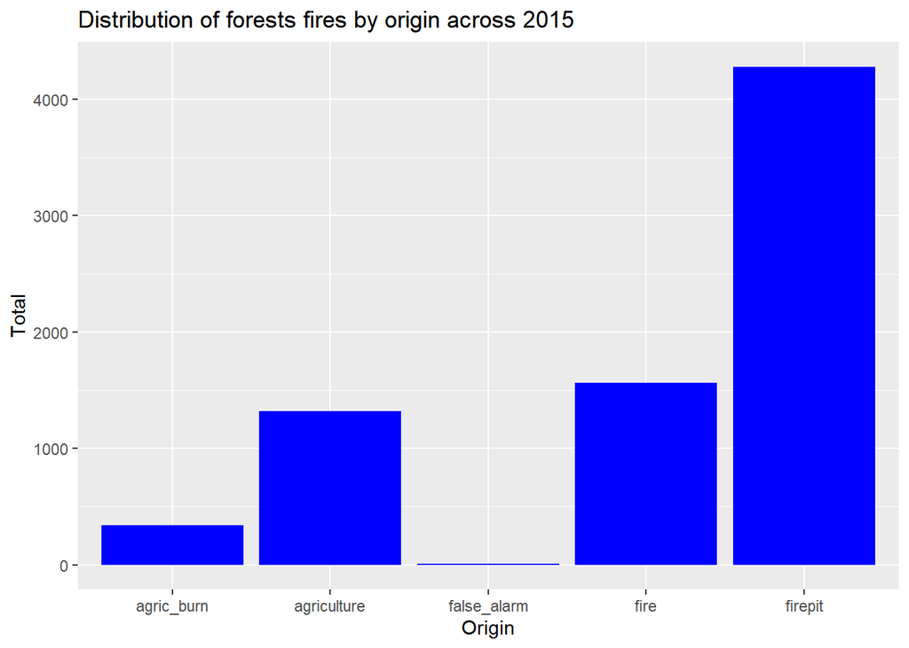

Conclusion: firepit was the origin of the most forests fires

6- Relationship between district, month and causes

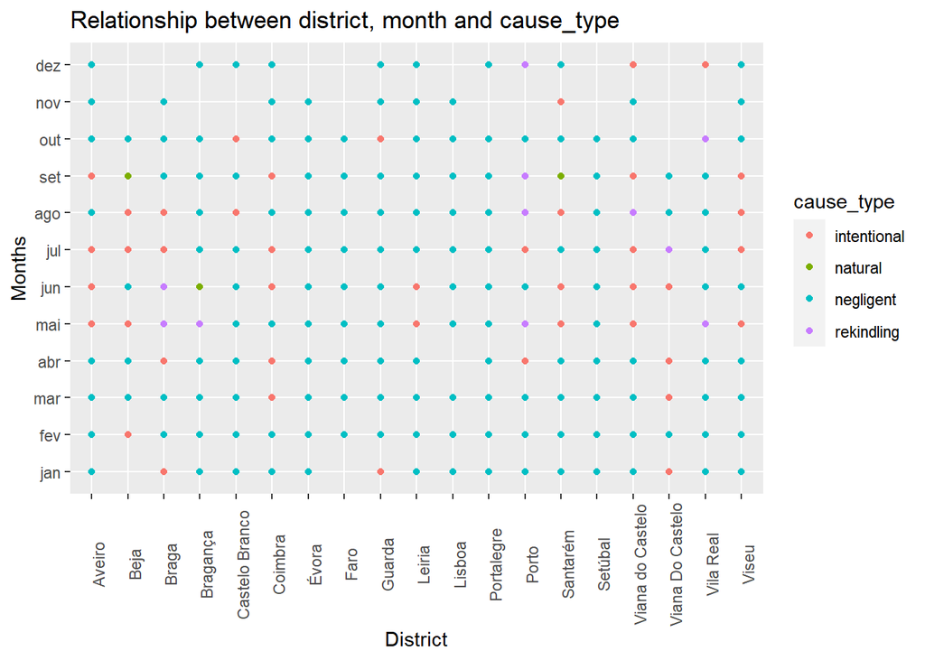

7- Relationship between region, month and causes

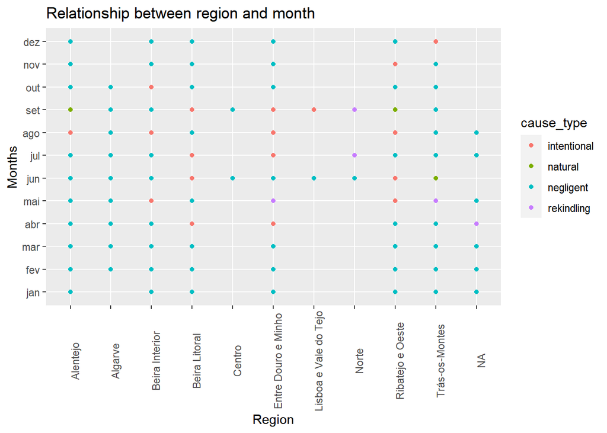